# Get data

```python
import pandas as pd
import numpy as np
import matplotlib.pyplot as plt
from statsmodels.stats.anova import AnovaRM
from scipy.stats import ttest_rel
from scipy.stats import mannwhitneyu
from scipy.stats import describe
from scipy.stats import ttest_ind
from scipy.stats import wilcoxon
import seaborn as sb
from mlxtend.evaluate import permutation_test
from math import comb
```

```python
#### read data from all endpoints
path = '~/Documents/Hollister/v1Data/' ### path and name will change depending on where data is stored
name = ['S20-20_Sorted_TEWL_V1_4Sponsor.xlsx','S20-20_Sorted_Erythema_V1_4Sponsor.xlsx','S20-20_Sorted_Denudation_V1_4Sponsor.xlsx']
```

```python
### read pH data
pHdf = pd.read_excel('~/Documents/Hollister/v1Data/S20-20_pH_V1_4Sponsor.xlsx',sheet_name='pH')
pHdf.head()
```

|  | ID | pH |
| --- | --- | --- |
| 0 | 1 | 6.630000 |
| 1 | 2 | 6.446667 |
| 2 | 3 | 6.176667 |
| 3 | 4 | 6.146667 |
| 4 | 5 | 6.453333 |

```python
dc = {'ID':[],'IPtype':[],'time':[],'TEWL':[],'Erythema':[],'Denudation':[],'pH':[]}
all_time = [0,3,5,6]
num_par = 25
num_type = 2
time = 4
for i in range(num_par):
    for j in range(len(all_time)):
        dc['ID'] += [i+1]
        dc['IPtype'] += ['A']
        dc['time'] += [all_time[j]]
        dc['pH'] += [pHdf['pH'].iloc[i]]
for i in range(num_par):
    for j in range(len(all_time)):
        dc['ID'] += [i+1]
        dc['IPtype'] += ['B']
        dc['time'] += [all_time[j]]
        dc['pH'] += [pHdf['pH'].iloc[i]]
```

```python
key = ['TEWL','Erythema','Denudation']
v11AB = {}
for doc in range(len(name)):
# for doc in range(2,3):
    v11=pd.read_excel(path+name[doc],sheet_name='v1-1')
    v11 = v11.reset_index(drop=True)
    v11_A = v11.iloc[:,:5];
    v11_A = v11_A.rename(columns={"#":"id","A BL": "0", "A 3": "3", "A 5": "5", "A 6": "6"})
    v11_A.insert(1,'IP','A')
    v11_B = v11.iloc[:,[0,5,6,7,8]];
    v11_B = v11_B.rename(columns={"#":"id","B BL": "0", "B 3": "3", "B 5": "5", "B 6": "6"})
    v11_B.insert(1,'IP','B')
    v11AB[key[doc]+"_A"] = v11_A
    v11AB[key[doc]+"_B"] = v11_B

    for i in range(v11_A.shape[0]):
        for j in range(len(all_time)):
            dc[key[doc]] += [(v11_A.iloc[i])[str(all_time[j])]]

    for i in range(v11_B.shape[0]):
        for j in range(len(all_time)):
            dc[key[doc]] += [(v11_B.iloc[i])[str(all_time[j])]]
```

```python
#### df2 stores merged dataset
df2 = pd.DataFrame(dc)
df2.head()
```

|  | ID | IPtype | time | TEWL | Erythema | Denudation | pH |
| --- | --- | --- | --- | --- | --- | --- | --- |
| 0 | 1 | A | 0 | 3.455 | 0 | 0 | 6.630000 |
| 1 | 1 | A | 3 | 9.760 | 2 | 0 | 6.630000 |
| 2 | 1 | A | 5 | 48.000 | 4 | 2 | 6.630000 |
| 3 | 1 | A | 6 | 68.475 | 6 | 2 | 6.630000 |
| 4 | 2 | A | 0 | 2.825 | 0 | 0 | 6.446667 |

```python
#### export the dataset in excel for future reuse
df2.to_excel("~/Desktop/v1Data/v1_all.xlsx")
```

```python
#### df3 stores TEWL data for analysis purpose
#### column name = peel number [0,3,5,6]
df3 = pd.concat([v11AB['TEWL_A'],v11AB['TEWL_B']])
df3.head()
```

|  | id | IP | 0 | 3 | 5 | 6 |
| --- | --- | --- | --- | --- | --- | --- |
| 0 | 1 | A | 3.455 | 9.76 | 48.000 | 68.475 |
| 1 | 2 | A | 2.825 | 2.61 | 9.495 | 17.370 |
| 2 | 3 | A | 3.220 | 13.94 | 41.250 | 53.725 |
| 3 | 4 | A | 3.515 | 18.59 | 57.540 | 78.340 |
| 4 | 5 | A | 4.905 | 28.52 | 68.465 | 77.770 |

```python
#### read data from all endpoints
path = '~/Documents/Hollister/v1Data/' ### path and name will change depending on where data is stored
name = 'v1_all.xlsx'
df2 = pd.read_excel(path+name,sheet_name='Sheet1')
```

# Initial Statistical Testing on TEWL (as a reference, skip to permutation test for more robust testing)

## paired t-test (assuming normal distribution)

- compare the means of the same group or item under two separate scenarios
- assumption might not hold true - see wilcoxon signed ranked test for more
- test whether there is significant difference between points related to treatment A compared to B

```python
ttest_results = []
ttest_pvalues = []
for i in range(num_par): ## loop through each subject
    test_df = df3[df3['id']== i+1] ## test_df contains data for treatment A and B for a single subject
    result, pvalue = ttest_rel(test_df.iloc[0,2:],test_df.iloc[1,2:]) ## test difference between 4 data points by A and 4 data points by B
    ttest_results += [result]
    ttest_pvalues += [pvalue]
## the operation above generates a ttest result and pvalue for each subject
## the code below describes the pvalues distribution
describe(ttest_pvalues)
```

```
DescribeResult(nobs=25, minmax=(0.07715025077422963, 0.7123467872550636), mean=0.2038531311059837, variance=0.026361970003181343, skewness=2.2018502140955825, kurtosis=4.102625915371707)
```

Data doesn't really satisfy the assumption of this method

## wilcoxon signed ranked test (alternative to paired t test)

test whether there is significant difference between points related to treatment A compared to B

```python
wsr_results = []
wsr_pvalues = []
significant_ind = []
high_cor =[]
middle_cor = []
## repeat the same operation as paired t-test
for i in range(num_par):
    test_df = df3[df3['id']== i+1]
    result, pvalue = wilcoxon(test_df.iloc[0,2:],test_df.iloc[1,2:])
    if pvalue <= 0.20: ## 0.2 cutoff too tight
        significant_ind += [i+1]
    ## if correlation is >= 0.6, categorize as high correlation between data for A and B
    elif pvalue >= 0.6:
        high_cor += [i+1]
    else:
        middle_cor += [i+1]
    wsr_results  += [result]
    wsr_pvalues += [pvalue]
significant_ind
```

```
[1, 5, 7, 9, 10, 12, 13, 14, 15, 19, 20, 22]
```

```python
high_cor
```

```
[2, 16, 21]
```

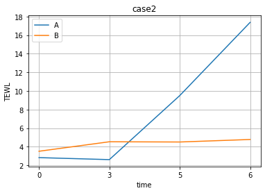

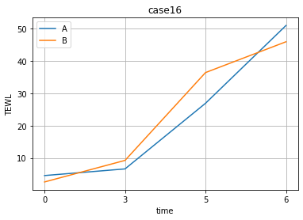

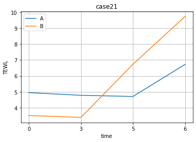

```python
for j in high_cor:
#     plt.figure(figsize=(4,4))
    plt.plot((df3[df3['id']==j]).iloc[0,2:])
    plt.plot((df3[df3['id']==j]).iloc[1,2:])
    plt.ylabel('TEWL')
    plt.xlabel('time')
    plt.title('case'+str(j))
    plt.legend(['A','B'])
    plt.grid(True)
    plt.show()
```

## Attempt to choose responders differently

## select for B > 20 for practical purposes in additional to significant testing

```python
### select for B > 20;
lastB = df2[(df2.IPtype=='B') & (df2.time==6)]
ids = lastB[lastB.TEWL >= 20].ID
print(ids)
print((np.array(wsr_pvalues))[ids-1])
index = np.argsort((np.array(wsr_pvalues))[ids-1])
selected_id = (np.array(ids))[index]
selected_id
```

```
103     1
111     3
119     5
123     6
155    14
163    16
167    17
175    19
191    23
195    24
199    25
Name: ID, dtype: int64
[0.125 0.375 0.125 0.25  0.125 0.875 0.25  0.125 0.375 0.25  0.25 ]
```

```
array([ 1,  5, 14, 19,  6, 17, 24, 25,  3, 23, 16])
```

```python
# significant and B>20
final_significant_id = [1,5,14,19]
```

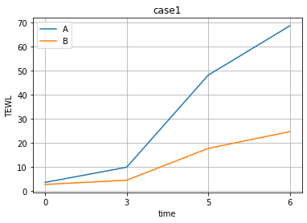

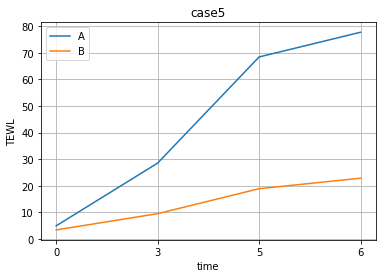

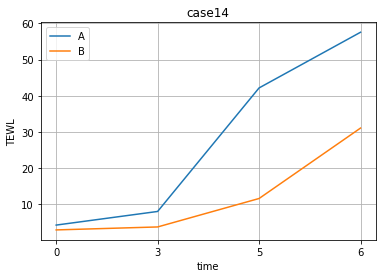

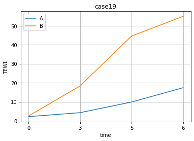

```python
for j in final_significant_id:
#     plt.figure(figsize=(4,4))
    plt.plot((df3[df3['id']==j]).iloc[0,2:])
    plt.plot((df3[df3['id']==j]).iloc[1,2:])
    plt.ylabel('TEWL')
    plt.xlabel('time')
    plt.title('case'+str(j))
    plt.legend(['A','B'])
    plt.grid(True)
    plt.show()
```

### only select for B > 20 and choose half

very few cases have statistically significant difference between A and B used half of cases with B>20 about half-half in site schemes

```python
# for j in selected_id[:5]:
# # for j in significant_ind:
# #     plt.figure(figsize=(4,4))
#     plt.plot((df3[df3['id']==j]).iloc[0,2:])
#     plt.plot((df3[df3['id']==j]).iloc[1,2:])
#     plt.ylabel('TEWL')
#     plt.xlabel('time')
#     plt.legend(['A','B'])
#     plt.title('case'+str(j))
#     plt.grid(True)
#     plt.show()
```

## mann-whitney (not assuming normal distribution)

test whether there is significant difference between points related to treatment A compared to B

Did not adjust for multiple comparisons (even smaller amount of cases )

```python
schema1 = [1,5,9,10,11,12,13,14,15,16,17,20,21] # 13
schema2 = [2,3,4,6,7,8,18,19,22,23,24,25] # 12

schema1_pvalue = np.array(wsr_pvalues)[np.array(schema1)-1]
schema2_pvalue = np.array(wsr_pvalues)[np.array(schema2)-1]

mannwhitneyu(schema1_pvalue,schema2_pvalue)
# not significant (u threshold = 53 for p=0.2, 47 for p = 0.1, 31 for p=0.05)
```

```
MannwhitneyuResult(statistic=53.0, pvalue=0.07613288269367105)
```

## An important observation: site effect

all selected participants except case 7,22 have site 9 - A1, site 10-B1; only patient 7,22 has site 9 - B1, site 10-A1. Is there an effect posed by site, or is it just a fluke?

# pearson correlation between TEWL, Erythema, and Denudation

```python
df2[df2['IPtype']=='A']
```

[output not shown]

100 rows × 6 columns

## correlation without accounting for individuals

```python
# correlate data regardless of treatments
df2.iloc[:,3:].corr(method='spearman')
```

|  | TEWL | Erythema | Denudation | pH |
| --- | --- | --- | --- | --- |
| TEWL | 1.000000 | 0.834795 | 0.449041 | -0.009126 |
| Erythema | 0.834795 | 1.000000 | 0.550595 | 0.077205 |
| Denudation | 0.449041 | 0.550595 | 1.000000 | 0.052313 |
| pH | -0.009126 | 0.077205 | 0.052313 | 1.000000 |

```python
# correlate data for only Flextend
(df2[df2['IPtype']=='A']).iloc[:,3:].corr(method='spearman')
```

|  | TEWL | Erythema | Denudation | pH |
| --- | --- | --- | --- | --- |
| TEWL | 1.000000 | 0.872712 | 0.464061 | -0.072023 |
| Erythema | 0.872712 | 1.000000 | 0.554569 | 0.035621 |
| Denudation | 0.464061 | 0.554569 | 1.000000 | 0.069448 |
| pH | -0.072023 | 0.035621 | 0.069448 | 1.000000 |

```python
# correlate data for only CeraPlus
(df2[df2['IPtype']=='B']).iloc[:,3:].corr(method='spearman')
```

|  | TEWL | Erythema | Denudation | pH |
| --- | --- | --- | --- | --- |
| TEWL | 1.000000 | 0.782464 | 0.342140 | 0.078965 |
| Erythema | 0.782464 | 1.000000 | 0.498686 | 0.124116 |
| Denudation | 0.342140 | 0.498686 | 1.000000 | 0.036471 |
| pH | 0.078965 | 0.124116 | 0.036471 | 1.000000 |

redness could be a potential indicator of TEWL, or vice versa; denudation do not work well from the correlation level

## correlation for individuals

```python
id_dict = {}
for i in range(num_par):
    typeB = (df2[df2['IPtype']=='B'])
    id_typeB = typeB[typeB.ID == i+1]
    T_E = id_typeB.iloc[:,3].corr(id_typeB.iloc[:,4],method='pearson')
    T_D = id_typeB.iloc[:,3].corr(id_typeB.iloc[:,5],method='pearson')
    E_D = id_typeB.iloc[:,4].corr(id_typeB.iloc[:,5],method='pearson')
    id_dict[i+1] = [T_E, T_D, E_D]

id_dict2 = {}
for i in range(num_par):
    typeA = df2[df2['IPtype']=='A']
    id_typeA = typeA[typeA.ID == i+1]
    T_E = id_typeA.iloc[:,3].corr(id_typeA.iloc[:,4],method='pearson')
    T_D = id_typeA.iloc[:,3].corr(id_typeA.iloc[:,5],method='pearson')
    E_D = id_typeA.iloc[:,4].corr(id_typeA.iloc[:,5],method='pearson')
    id_dict2[i+1] = [T_E, T_D, E_D]
```

```python
#### correlation between data for Ceraplus
#### in the order (TEWL vs Erythema), (TEWL vs Denudation), (Erythema vs Denudation)
id_dict
```

```
{1: [0.8363928130963322, 0.7747575984966896, 0.9771398364036774],
 2: [nan, nan, nan],
 3: [0.9778991811300475, 0.9535365470299118, 0.9434563530497265],
 4: [0.9292710486423656, nan, nan],
 5: [0.9723297334102246, 0.692455784738521, 0.5222329678670935],
 6: [0.9105445499322248, 0.8266602908739005, 0.5222329678670935],
 7: [0.667439117621864, nan, nan],
 8: [0.8265287431121572, 0.9383529696390759, 0.8528028654224418],
 9: [0.9769784288718018, 0.7814915961062291, 0.8703882797784891],
 10: [0.6960796058193859, nan, nan],
 11: [nan, nan, nan],
 12: [nan, nan, nan],
 13: [0.8915194461802004, 0.8915194461802004, 1.0],
 14: [0.7941916765931488, nan, nan],
 15: [nan, nan, nan],
 16: [0.9602409203841162, nan, nan],
 17: [0.8431150960865259, 0.703919091779214, 0.816496580927726],
 18: [0.960900191149257, nan, nan],
 19: [0.8923202552972472, nan, nan],
 20: [0.8817986482013177, nan, nan],
 21: [0.5142987898626478, nan, nan],
 22: [0.913377294262445, nan, nan],
 23: [0.9946411452433765, 0.43371632070232763, 0.36514837167011077],
 24: [0.9847686469879112, nan, nan],
 25: [0.7094196113719449, -0.044882133045529765, 0.5773502691896257]}
```

```python
#### correlation between data for Flextend
#### in the order (TEWL vs Erythema), (TEWL vs Denudation), (Erythema vs Denudation)
id_dict2
```

```
{1: [0.9695372270274388, 0.9595483727908317, 0.8944271909999159],
 2: [0.9991696015057423, 0.13577386583241668, 0.17407765595569782],
 3: [0.9960124722461773, 0.958107774218106, 0.9434563530497265],
 4: [0.9786613527243803, 0.7510893433784039, 0.8372183582789214],
 5: [0.9529218111981926, 0.6409298579091699, 0.5773502691896257],
 6: [0.9627786719165595, 0.5516995190346412, 0.5703518254720302],
 7: [0.8855903440300863, 0.3427152457945753, 0.674199862463242],
 8: [0.9435529878987137, 0.9691156154470563, 0.9945577827230725],
 9: [0.9626708913465203, 0.7104142724624131, 0.8703882797784891],
 10: [0.8620144159436308, nan, nan],
 11: [0.9335269900380643, 0.9335269900380643, 1.0],
 12: [0.9527311523175449, -0.4307010308581587, -0.16012815380508713],
 13: [0.9746644659461066, 0.96928528334183, 0.911322376865767],
 14: [0.9790366008342709, 0.7561553138926688, 0.8703882797784891],
 15: [0.9839915846169754, 0.7459198391782027, 0.676481425202546],
 16: [0.8846213090404589, 0.8846213090404589, 1.0],
 17: [0.8239654577150635, 0.5891844812803121, 0.9428090415820632],
 18: [0.8273595724715989, nan, nan],
 19: [0.8787321374225164, 0.8787321374225164, 1.0],
 20: [0.9979464224728248, nan, nan],
 21: [0.556094463437468, nan, nan],
 22: [0.9885046427535866, 0.9111467137431212, 0.9622504486493761],
 23: [0.9873477290569794, 0.3412817326036747, 0.22549380840084865],
 24: [0.9968216429229038, 0.4867359538922419, 0.42365927286816163],
 25: [0.6751565373650654, 0.517879539694531, -0.24618298195866548]}
```

redness is consistent with TEWL for most individuals, if paired with image processing of redness scale, could potentially predict TEWL (see R code regression)

# wipe_dict stores data before and after wipe for all three measures

```python
path = "~/Documents/Hollister/v1Data/"
names = name = ['S20-20_Sorted_TEWL_V1_4Sponsor.xlsx','S20-20_Sorted_Erythema_V1_4Sponsor.xlsx','S20-20_Sorted_Denudation_V1_4Sponsor.xlsx']
key = ['TEWL','Erythema','Denudation']
wipe_dict = {}
for doc in range(len(name)):
    v12=pd.read_excel(path+name[doc],sheet_name='v1-2')
    wipe_dict[key[doc]] = v12
wipe_dict['TEWL'].head()
```

|  | ID | A6 | A6post | B6 | B6post |
| --- | --- | --- | --- | --- | --- |
| 0 | 1 | 68.475 | 73.545 | 24.545 | 35.785 |
| 1 | 2 | 17.370 | 19.670 | 4.775 | 5.675 |
| 2 | 3 | 53.725 | 48.840 | 52.730 | 53.405 |
| 3 | 4 | 78.340 | 80.805 | 10.670 | 13.495 |
| 4 | 5 | 77.770 | 76.630 | 22.835 | 29.125 |

## pre and post wipe TEWL data figures

```python
wipe_dict['TEWL'].index
```

```
RangeIndex(start=0, stop=25, step=1)
```

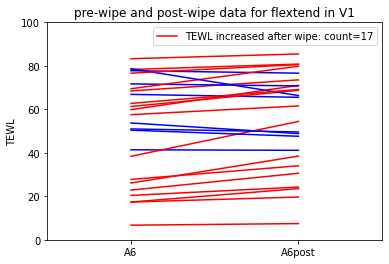

```python
# plt.figure(figsize=(4,4))
cnt=0
for i in wipe_dict['TEWL'].index:
    if wipe_dict['TEWL'].iloc[i,1] <= wipe_dict['TEWL'].iloc[i,2]:
        plt.plot(wipe_dict['TEWL'].iloc[i,1:3],c='r')
        cnt += 1
    elif wipe_dict['TEWL'].iloc[i,1] > wipe_dict['TEWL'].iloc[i,2]:
        plt.plot(wipe_dict['TEWL'].iloc[i,1:3],c='b')
plt.ylim([0,100])
plt.xlim([-0.5,1.5])
plt.ylabel('TEWL')
plt.legend(['TEWL increased after wipe: count='+str(cnt)])
plt.title('pre-wipe and post-wipe data for flextend in V1')
plt.savefig('reportplots/v1wipeA.png')
```

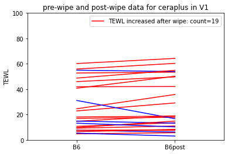

```python
# plt.figure(figsize=(4,4))
cnt=0
for i in wipe_dict['TEWL'].index:
    if wipe_dict['TEWL'].iloc[i,3] <= wipe_dict['TEWL'].iloc[i,4]:
        plt.plot(wipe_dict['TEWL'].iloc[i,3:5],c='r')
        cnt += 1
    elif wipe_dict['TEWL'].iloc[i,3] > wipe_dict['TEWL'].iloc[i,4]:
        plt.plot(wipe_dict['TEWL'].iloc[i,3:5],c='b')
plt.ylim([0,100])
plt.xlim([-0.5,1.5])
plt.ylabel('TEWL')
plt.legend(['TEWL increased after wipe: count='+str(cnt)])
plt.title('pre-wipe and post-wipe data for ceraplus in V1')
plt.savefig('reportplots/v1wipeB.png')
```

```python
wipe_dict['TEWL'].head()
```

|  | ID | A6 | A6post | B6 | B6post |
| --- | --- | --- | --- | --- | --- |
| 0 | 1 | 68.475 | 73.545 | 24.545 | 35.785 |
| 1 | 2 | 17.370 | 19.670 | 4.775 | 5.675 |
| 2 | 3 | 53.725 | 48.840 | 52.730 | 53.405 |
| 3 | 4 | 78.340 | 80.805 | 10.670 | 13.495 |
| 4 | 5 | 77.770 | 76.630 | 22.835 | 29.125 |

## TEWL of A6, A6post, B6, B6post for subjects with increased post-wipe TEWL in V1

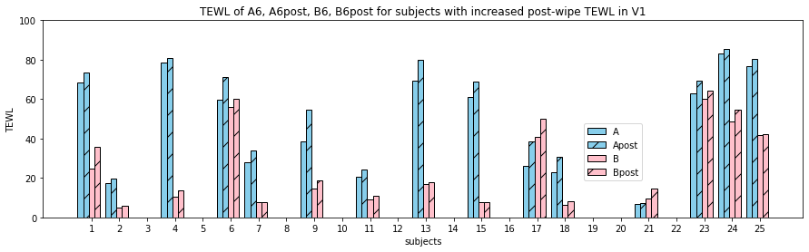

```python
tewl_wipe = wipe_dict['TEWL']


plt.figure(figsize=(15,4))
cnt=0
for i in tewl_wipe.ID.unique():
    A6 = tewl_wipe[tewl_wipe.ID==i]["A6"].tolist()[0]
    A6post= tewl_wipe[tewl_wipe.ID==i]["A6post"].tolist()[0]
    B6 = tewl_wipe[tewl_wipe.ID==i]["B6"].tolist()[0]
    B6post = tewl_wipe[tewl_wipe.ID==i]["B6post"].tolist()[0]
    if A6 <= A6post and B6 <= B6post:
        plt.bar([i-0.4],[A6],width=0.2,edgecolor='black',color='skyblue')
        plt.bar([i-0.2],[A6post],width=0.2,edgecolor='black',color='skyblue',hatch="/")
        plt.bar([i],[B6],width=0.2,edgecolor='black',color='pink')
        plt.bar([i+0.2],[B6post],width=0.2,color='pink',edgecolor='black',hatch="/")
        cnt += 1
plt.xticks(tewl_wipe.ID.unique())
plt.ylim([0,100])
plt.ylabel('TEWL')
plt.xlabel('subjects')
plt.legend(['A','Apost','B','Bpost'],loc='best', bbox_to_anchor=(0.5, 0., 0.5, 0.5))
plt.title('TEWL of A6, A6post, B6, B6post for subjects with increased post-wipe TEWL in V1')
plt.savefig('reportplots/v1wipeAB.png')
plt.show()
```

## percentage change in subjects for flextend(A) and ceraplus(B) in V1

TEWL percentage change: (post-wipe - pre-wipe)/(pre-wipe) * 100

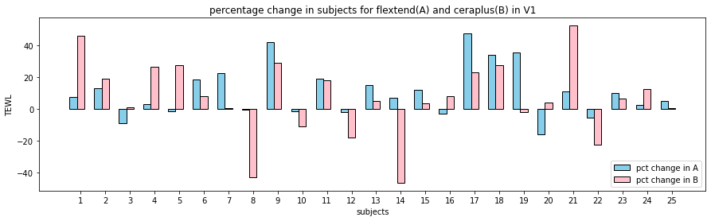

```python
tewl_wipe = wipe_dict['TEWL']


plt.figure(figsize=(15,4))
cnt=0
Apct_list=[]
Bpct_list=[]
for i in tewl_wipe.ID.unique():
    wid = 0.3
    A6 = tewl_wipe[tewl_wipe.ID==i]["A6"].tolist()[0]
    A6post= tewl_wipe[tewl_wipe.ID==i]["A6post"].tolist()[0]
    Apct = (A6post-A6)/A6*100
    B6 = tewl_wipe[tewl_wipe.ID==i]["B6"].tolist()[0]
    B6post = tewl_wipe[tewl_wipe.ID==i]["B6post"].tolist()[0]
    Bpct = (B6post-B6)/B6*100
#     if A6 <= A6post and B6 <= B6post:
    plt.bar([i-wid],[Apct],width=wid,edgecolor='black',color='skyblue')
    plt.bar([i],[Bpct],width=wid,edgecolor='black',color='pink')
    cnt += 1
    Apct_list += [Apct]
    Bpct_list += [Bpct]
plt.xticks(tewl_wipe.ID.unique())
# plt.ylim([0,100])
plt.ylabel('TEWL')
plt.xlabel('subjects')
plt.legend(['pct change in A','pct change in B'],loc='best', bbox_to_anchor=(0.5, 0., 0.5, 0.5))
plt.title('percentage change in subjects for flextend(A) and ceraplus(B) in V1')
plt.savefig('reportplots/v1pctAB.png')
plt.show()
```

### percentage change distribution for Flextend and CeraPlus

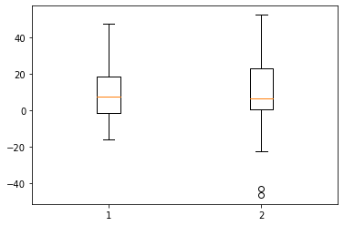

```python
plt.boxplot({'A':Apct_list,'B':Bpct_list}.values())
plt.show()
```

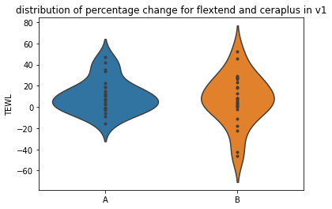

```python
sb.violinplot(data=pd.DataFrame({'A':Apct_list,'B':Bpct_list}),inner="point")
plt.ylabel('TEWL')
plt.title('distribution of percentage change for flextend and ceraplus in v1')
plt.savefig('reportplots/v1pctviolin.png')
plt.show()
```

# !! permutation test

## permutation test on pre and post-wipe data

```python
### (A and B pre) vs (A and B post)
TEWLpre = pd.concat([wipe_dict['TEWL'].iloc[:,1],wipe_dict['TEWL'].iloc[:,3]])
TEWLpost = pd.concat([wipe_dict['TEWL'].iloc[:,2],wipe_dict['TEWL'].iloc[:,4]])
ttest_rel(TEWLpre,TEWLpost)
```

```
Ttest_relResult(statistic=-3.2095292000401696, pvalue=0.002347051593578495)
```

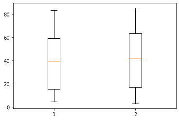

```python
plt.boxplot({'pre':TEWLpre,'post':TEWLpost}.values())
plt.show()
```

### TEWL

```python
#### TEWL
p = 0
p_values = []
for n in range(20):
    p_value = permutation_test(TEWLpre, TEWLpost,
                                   method='approximate',
                                   num_rounds=1000,
                                   seed=n)
    if p_value < 0.05:
        p += 1
    p_values += [p_value]
# print(p_values)
print(p,'out of 50 permutation tests gives significant p value')
```

[output not shown]

Permutation test shows that pre-wipe and post-wipe TEWL data are not significantly different for pooled data on Flextend and CeraPlus.

### Erythema

```python
Epre = pd.concat([wipe_dict['Erythema'].iloc[:,1],wipe_dict['Erythema'].iloc[:,3]])
Epost = pd.concat([wipe_dict['Erythema'].iloc[:,2],wipe_dict['Erythema'].iloc[:,4]])
ttest_rel(Epre,Epost)
```

```
Ttest_relResult(statistic=-5.193989612031164, pvalue=3.964226673245827e-06)
```

```python
#### Erythema
p = 0
p_values = []
for n in range(50):
    p_value = permutation_test(Epre, Epost,
                                   method='approximate',
                                   num_rounds=1000,
                                   seed=n)
    if p_value < 0.05:
        p += 1
    p_values += [p_value]
# print(p_values)
print(p,'out of 50 permutation tests gives significant p value')
```

```
0 out of 50 permutation tests gives significant p value
```

Permutation test shows that pre-wipe and post-wipe erythema data are not significantly different for pooled data on Flextend and CeraPlus.

### Denudation

```python
Dpre = pd.concat([wipe_dict['Denudation'].iloc[:,1],wipe_dict['Denudation'].iloc[:,3]])
Dpost = pd.concat([wipe_dict['Denudation'].iloc[:,2],wipe_dict['Denudation'].iloc[:,4]])
ttest_rel(Dpre,Dpost)
```

[output not shown]

```python
#### Denudation
p = 0
p_values = []
for n in range(50):
    p_value = permutation_test(Dpre, Dpost,
                                   method='approximate',
                                   num_rounds=1000,
                                   seed=n)
    if p_value < 0.05:
        p += 1
    p_values += [p_value]
# print(p_values)
print(p,'out of 50 permutation tests gives significant p value')
```

```
0 out of 50 permutation tests gives significant p value
```

Permutation test shows that pre-wipe and post-wipe denudation data are not significantly different for pooled data on Flextend and CeraPlus.

```python
key = ["TEWL","Erythema","Denudation"]
for i in key:
    p = 0
    p_values = []
    for n in range(50):
        p_value = permutation_test(wipe_dict[i].iloc[:,1], wipe_dict[i].iloc[:,2],
                                       method='approximate',
                                       num_rounds=1000,
                                       seed=n)
        if p_value < 0.05:
            p += 1
        p_values += [p_value]
#     print(p_values)
    print(p,'out of 50 permutation tests gives significant p value for Apre vs Apost-'+i)

    p = 0
    p_values = []
    for n in range(50):
        p_value = permutation_test(wipe_dict[i].iloc[:,3], wipe_dict[i].iloc[:,4],
                                       method='approximate',
                                       num_rounds=1000,
                                       seed=n)
        if p_value < 0.05:
            p += 1
        p_values += [p_value]
#     print(p_values)
    print(p,'out of 50 permutation tests gives significant p value for Bpre vs Bpost-'+i)
```

```
0 out of 50 permutation tests gives significant p value for Apre vs Apost-TEWL
0 out of 50 permutation tests gives significant p value for Bpre vs Bpost-TEWL
0 out of 50 permutation tests gives significant p value for Apre vs Apost-Erythema
0 out of 50 permutation tests gives significant p value for Bpre vs Bpost-Erythema
0 out of 50 permutation tests gives significant p value for Apre vs Apost-Denudation
0 out of 50 permutation tests gives significant p value for Bpre vs Bpost-Denudation
```

```python
# key = TEWL,Erythema,Denudation
# for i in key:
#     print(wilcoxon(wipe_dict[i].iloc[:,1],wipe_dict[i].iloc[:,2]))
#     print(wilcoxon(wipe_dict[i].iloc[:,3],wipe_dict[i].iloc[:,4]))
#     print(ttest_rel(wipe_dict[i].iloc[:,1],wipe_dict[i].iloc[:,2]))
#     print(ttest_rel(wipe_dict[i].iloc[:,3],wipe_dict[i].iloc[:,4]))
```

Post wipe value don't differ significantly from pre-wipe for TEWL_A&B, Erythema_A & B, Denudation_A&B

## permutation test on per strip TEWL increase during each period of measurement

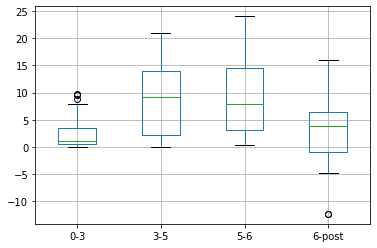

```python
# all normalized to one strip
df3['0-3'] = (df3['3'] - df3['0']) /3
df3['3-5'] = (df3['5'] - df3['3']) /2
df3['5-6'] = df3['6'] - df3['5']
df3['6-post'] = wipe_dict['TEWL'].iloc[:,2]-wipe_dict['TEWL'].iloc[:,1]
df3
df3.boxplot(column=['0-3','3-5','5-6','6-post'])
plt.show()
```

```python
for i in [('0-3','3-5'),('0-3','5-6'),('3-5','5-6')]:
    p = 0
    p_values = []
    for n in range(50):
        p_value = permutation_test(df3[i[0]], df3[i[1]],
                                       method='approximate',
                                       num_rounds=1000,
                                       seed=n)
        if p_value < 0.05:
            p += 1
        p_values += [p_value]
#     print(p_values)
    print(p,'out of 50 permutation tests gives significant p value between '+i[0]+' and '+i[1])
```

```
50 out of 50 permutation tests gives significant p value between 0-3 and 3-5
50 out of 50 permutation tests gives significant p value between 0-3 and 5-6
0 out of 50 permutation tests gives significant p value between 3-5 and 5-6
```

3-5 and 5-6 are not systematically different, 0-3 are systematically different from 3-5

# QQ plot for per peel TEWL increase to check whether each period per peel increase come from same distribution

If the dots align with the diagonal line (red), then the two tested data potentially come from the same distribution

general trend:

- per peel TEWL increase at peel3-5 and peel 5-6 are likely to have come from the same distribution, for Flextend and Ceraplus respectively and rogether.
- (TEWl amount) averaged increase of 3-5 (divided by 2) and increase of 5-6 might be from the same distribution, but are systematically difference from 0-3.(pooled)

### Flextend

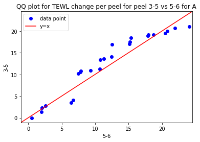

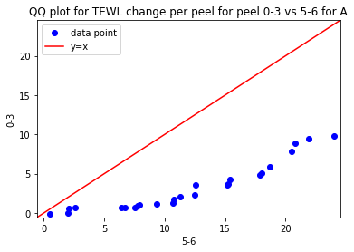

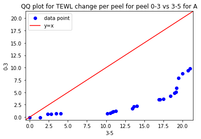

```python
df3A = df3[df3.IP=='A']

from statsmodels.graphics.gofplots import qqplot_2samples
qqplot_2samples(df3A['3-5'],df3A['5-6'],line="45",xlabel="5-6",ylabel="3-5")
plt.title("QQ plot for TEWL change per peel for peel 3-5 vs 5-6 for A")
plt.legend(["data point","y=x"])
plt.savefig('reportplots/Aavg3-5vs5-6.png')
plt.show()

qqplot_2samples(df3A['0-3'],df3A['5-6'],line="45",xlabel="5-6",ylabel="0-3")
plt.title("QQ plot for TEWL change per peel for peel 0-3 vs 5-6 for A")
plt.legend(["data point","y=x"])
plt.savefig('reportplots/Aavg0-3vs5-6.png')
plt.show()

qqplot_2samples(df3A['0-3'],df3A['3-5'],line="45",xlabel="3-5",ylabel="0-3")
plt.title("QQ plot for TEWL change per peel for peel 0-3 vs 3-5 for A")
plt.legend(["data point","y=x"])
plt.savefig('reportplots/Aavg0-3vs3-5.png')
plt.show()
```

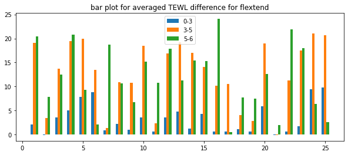

```python
w=0.2
plt.figure(figsize=(10,4))
plt.bar(x=np.arange(1,26,1)-w,height=df3A['0-3'],width=w)
plt.bar(x=np.arange(1,26,1),height=df3A['3-5'],width=w)
plt.bar(x=np.arange(1,26,1)+w,height=df3A['5-6'],width=w)
plt.title("bar plot for averaged TEWL difference for flextend")
plt.legend(["0-3","3-5","5-6"])
plt.show()
```

### Ceraplus

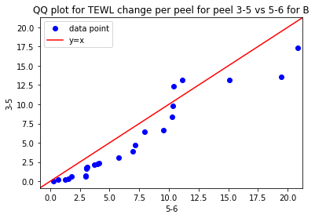

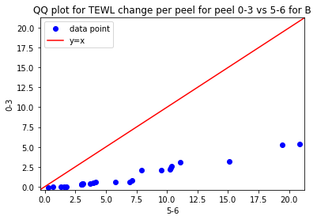

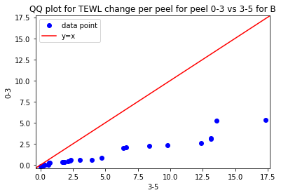

```python
df3B = df3[df3.IP=='B']

from statsmodels.graphics.gofplots import qqplot_2samples
qqplot_2samples(df3B['3-5'],df3B['5-6'],line="45",xlabel="5-6",ylabel="3-5")
plt.title("QQ plot for TEWL change per peel for peel 3-5 vs 5-6 for B")
plt.legend(["data point","y=x"])
plt.savefig('reportplots/Bavg3-5vs5-6.png')
plt.show()

qqplot_2samples(df3B['0-3'],df3B['5-6'],line="45",xlabel="5-6",ylabel="0-3")
plt.title("QQ plot for TEWL change per peel for peel 0-3 vs 5-6 for B")
plt.legend(["data point","y=x"])
plt.savefig('reportplots/Bavg0-3vs5-6.png')
plt.show()

qqplot_2samples(df3B['0-3'],df3B['3-5'],line="45",xlabel="3-5",ylabel="0-3")
plt.title("QQ plot for TEWL change per peel for peel 0-3 vs 3-5 for B")
plt.legend(["data point","y=x"])
plt.savefig('reportplots/Bavg0-3vs3-5.png')
plt.show()
```

### both treatments

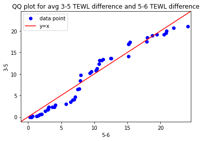

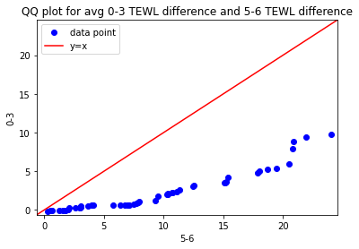

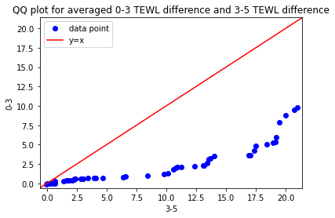

```python
from statsmodels.graphics.gofplots import qqplot_2samples
qqplot_2samples(df3['3-5'],df3['5-6'],line="45",xlabel="5-6",ylabel="3-5")
plt.title("QQ plot for avg 3-5 TEWL difference and 5-6 TEWL difference")
plt.legend(["data point","y=x"])
plt.show()
qqplot_2samples(df3['0-3'],df3['5-6'],line="45",xlabel="5-6",ylabel="0-3")
plt.title("QQ plot for avg 0-3 TEWL difference and 5-6 TEWL difference")
plt.legend(["data point","y=x"])
plt.show()
qqplot_2samples(df3['0-3'],df3['3-5'],line="45",xlabel="3-5",ylabel="0-3")
plt.title("QQ plot for averaged 0-3 TEWL difference and 3-5 TEWL difference")
plt.legend(["data point","y=x"])
plt.show()
```

# Grouping based on TEWL

## pearsoncorr between individuals (not very useful)

```python
dfA = df3[df3.IP=='A']
dfA = dfA.iloc[:,2:6]
dfA = dfA.rename(columns={"0":0, "3":3, "5":5, "6":6})
dfA = dfA.T
dfA.columns = np.arange(1,26,1)
```

```python
dfB = df3[df3.IP=='B']
dfB = dfB.iloc[:,2:6]
dfB = dfB.rename(columns={"0":0, "3":3, "5":5, "6":6})
dfB = dfB.T
dfB.columns = np.arange(1,26,1)
```

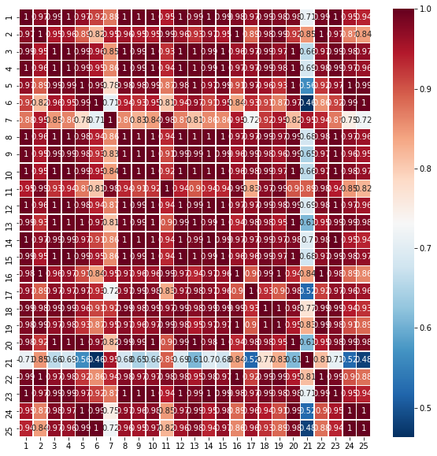

```python
pearsoncorr = (dfA).corr(method='pearson')
fig, ax = plt.subplots(figsize=(10,10))
sb.heatmap(pearsoncorr,
#             xticklabels=[1,2,3,4,5],
#             yticklabels=[1,2,3,4,5],
            cmap='RdBu_r',
            annot=True,
            linewidth=0.5,
            ax = ax)
```

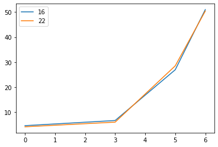

```python
# array = [1,3,4,8,10,12,14,15,23] # no change 3-6
# array = [5,9,20,13,24,6,25,17] # flatten 5-6
# array = [2,11,19,18] # steeper 5-6
array = [16,22] # steeper 5-6 steeper 3-5
# array = [7,21] # different from all other ones

for i in array:
    plt.plot(dfA[i])
    plt.legend(array)
```

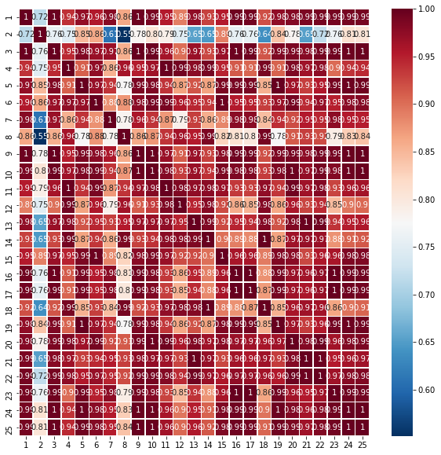

```python
# dfA_drop = dfA.drop(labels=[7,21],axis=1)
pearsoncorr = (dfB).corr(method='pearson')
fig, ax = plt.subplots(figsize=(10,10))
sb.heatmap(pearsoncorr,
#             xticklabels=[1,2,3,4,5],
#             yticklabels=[1,2,3,4,5],
            cmap='RdBu_r',
            annot=True,
            linewidth=0.5,
            ax = ax)
```

```python
(dfA.T).to_csv("~/Desktop/v1Data/dataA")
```

## hierarchical clustering

### For A

```python
cluster = 2
```

```python
# complete linkage clustering: largest distance between items in two clusters

from sklearn.cluster import AgglomerativeClustering
clustering = AgglomerativeClustering(n_clusters=cluster,linkage='complete').fit(dfA.T)
clustering.labels_
```

```
array([0, 1, 0, 0, 0, 0, 1, 0, 0, 0, 1, 0, 0, 0, 0, 0, 1, 1, 1, 0, 1, 0,
       0, 0, 0])
```

```
[ 1  3  4  5  6  8  9 10 12 13 14 15 16 20 22 23 24 25]
[ 2  7 11 17 18 19 21]
```

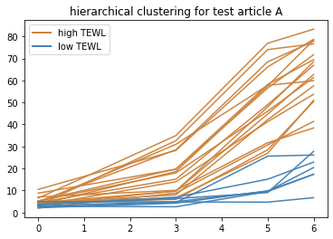

```python
from matplotlib.lines import Line2D
legend_elements = [Line2D([0], [0], color='peru', lw=2, label='high TEWL'),
                   Line2D([0], [0], color='steelblue', lw=2, label='low TEWL')]

color = ['peru','steelblue','r']

for i in range(cluster):
    label_idx = np.where(np.array(clustering.labels_==i)==True)[0]+1
    print(label_idx)
    plt.plot(dfA[label_idx],color[i])
plt.legend(['high TEWL','low TEWL'])
plt.title('hierarchical clustering for test article A')
plt.legend(handles=legend_elements)
plt.savefig('hierarchical clustering for test article A in v1')
#     plt.show()
```

```python
from scipy.cluster.hierarchy import dendrogram
def plot_dendrogram(model, **kwargs):
    # Create linkage matrix and then plot the dendrogram

    # create the counts of samples under each node
    counts = np.zeros(model.children_.shape[0])
    n_samples = len(model.labels_)
    for i, merge in enumerate(model.children_):
        current_count = 0
        for child_idx in merge:
            if child_idx < n_samples:
                current_count += 1  # leaf node
            else:
                current_count += counts[child_idx - n_samples]
        counts[i] = current_count

    linkage_matrix = np.column_stack([model.children_, model.distances_,
                                      counts]).astype(float)

    # Plot the corresponding dendrogram
    dendrogram(linkage_matrix, **kwargs)
```

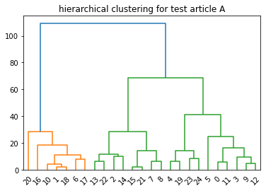

```python
model = AgglomerativeClustering(linkage='complete',distance_threshold=0, n_clusters=None)
model = model.fit(dfA.T)
plot_dendrogram(model)
plt.title('hierarchical clustering for test article A')
```

### for B

```python
dfB = df3[df3.IP=='B']
dfB = dfB.iloc[:,2:6]
dfB = dfB.rename(columns={"0":0, "3":3, "5":5, "6":6})
dfB = dfB.T
dfB.columns = np.arange(1,26,1)
```

```python
dfB.head()
```

|  | 1 | 2 | 3 | 4 | 5 | 6 | 7 | 8 | 9 | 10 | ... | 16 | 17 | 18 | 19 | 20 | 21 | 22 | 23 | 24 | 25 |
| --- | --- | --- | --- | --- | --- | --- | --- | --- | --- | --- | --- | --- | --- | --- | --- | --- | --- | --- | --- | --- | --- |
| 0 | 2.610 | 3.510 | 4.32 | 4.575 | 3.370 | 6.095 | 3.500 | 3.490 | 5.530 | 6.420 | ... | 2.590 | 1.915 | 4.010 | 2.475 | 5.225 | 3.515 | 4.015 | 5.705 | 8.715 | 6.945 |
| 3 | 4.370 | 4.530 | 11.38 | 5.640 | 9.485 | 22.205 | 3.150 | 3.380 | 7.185 | 8.265 | ... | 9.260 | 8.085 | 4.070 | 18.300 | 7.635 | 3.395 | 4.810 | 15.230 | 18.065 | 14.805 |
| 5 | 17.570 | 4.505 | 37.62 | 6.975 | 18.890 | 35.015 | 6.880 | 3.745 | 11.720 | 11.760 | ... | 36.425 | 32.810 | 4.715 | 44.560 | 12.300 | 6.730 | 9.025 | 49.915 | 37.630 | 31.595 |
| 6 | 24.545 | 4.775 | 52.73 | 10.670 | 22.835 | 55.870 | 7.525 | 5.290 | 14.700 | 14.825 | ... | 45.955 | 40.730 | 6.480 | 54.940 | 18.055 | 9.730 | 13.160 | 60.190 | 48.725 | 41.920 |

4 rows × 25 columns

```python
clustering2 = AgglomerativeClustering(n_clusters=cluster,linkage='complete').fit(dfB.T)
clustering2.labels_
```

```
array([0, 0, 1, 0, 0, 1, 0, 0, 0, 0, 0, 0, 0, 0, 0, 1, 1, 0, 1, 0, 0, 0,
       1, 1, 1])
```

```
[ 1  2  4  5  7  8  9 10 11 12 13 14 15 18 20 21 22]
[ 3  6 16 17 19 23 24 25]
```

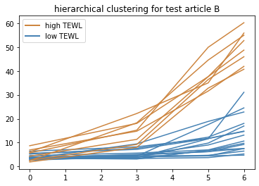

```python
color = ['steelblue','peru','g']
legend_elements = [Line2D([0], [0], color='peru', lw=2, label='high TEWL'),
                   Line2D([0], [0], color='steelblue', lw=2, label='low TEWL')]


for i in range(cluster):
    label_idx = np.where(np.array(clustering2.labels_==i)==True)[0]+1
    print(label_idx)
    plt.plot(dfB[label_idx],color[i])
plt.title('hierarchical clustering for test article B')
plt.legend(handles=legend_elements)
plt.savefig('reportplots/hierarchical clustering for test article B.png')
#     plt.show()
```

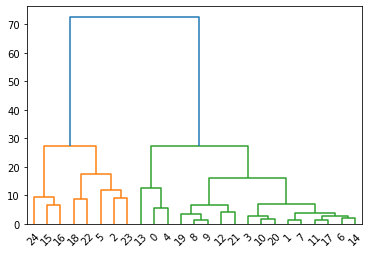

```python
model2 = AgglomerativeClustering(linkage='complete',distance_threshold=0, n_clusters=None)
model2 = model2.fit(dfB.T)
plot_dendrogram(model2)
```

### for A+B

```python
dfAB = dfA.add(dfB)
dfAB = (dfAB.T).rename(columns={"0":0, "3":3, "5":5, "6":6})
dfAB = dfAB.T
dfAB.head()
```

|  | 1 | 2 | 3 | 4 | 5 | 6 | 7 | 8 | 9 | 10 | ... | 16 | 17 | 18 | 19 | 20 | 21 | 22 | 23 | 24 | 25 |
| --- | --- | --- | --- | --- | --- | --- | --- | --- | --- | --- | --- | --- | --- | --- | --- | --- | --- | --- | --- | --- | --- |
| 0 | 6.065 | 6.335 | 7.540 | 8.090 | 8.275 | 10.545 | 7.180 | 5.460 | 12.595 | 15.170 | ... | 7.160 | 4.325 | 7.50 | 4.630 | 15.700 | 8.465 | 8.125 | 10.115 | 15.235 | 10.130 |
| 3 | 14.130 | 7.140 | 25.320 | 24.230 | 38.005 | 53.160 | 9.450 | 12.185 | 17.260 | 27.910 | ... | 15.885 | 12.540 | 11.02 | 22.535 | 35.835 | 8.180 | 10.780 | 24.915 | 52.990 | 47.430 |
| 5 | 65.570 | 14.000 | 78.870 | 64.515 | 87.355 | 92.795 | 15.925 | 34.430 | 43.395 | 68.295 | ... | 63.350 | 58.405 | 19.82 | 54.400 | 78.440 | 11.440 | 37.510 | 94.645 | 114.530 | 105.620 |
| 6 | 93.020 | 22.145 | 106.455 | 89.010 | 100.605 | 115.735 | 35.290 | 46.685 | 53.100 | 86.520 | ... | 96.940 | 66.835 | 29.34 | 72.300 | 96.755 | 16.450 | 63.575 | 122.915 | 132.020 | 118.555 |

4 rows × 25 columns

```python
clustering3 = AgglomerativeClustering(n_clusters=cluster,linkage='complete').fit(dfAB.T)
clustering3.labels_
```

```
array([0, 1, 0, 0, 0, 0, 1, 1, 1, 0, 1, 0, 0, 0, 0, 0, 0, 1, 0, 0, 1, 1,
       0, 0, 0])
```

```
[ 1  3  4  5  6 10 12 13 14 15 16 17 19 20 23 24 25]
[ 2  7  8  9 11 18 21 22]
```

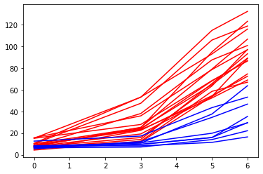

```python
color = ['r','b','g']
for i in range(cluster):
    label_idx = np.where(np.array(clustering3.labels_==i)==True)[0]+1
    print(label_idx)
    plt.plot(dfAB[label_idx],color[i])
#     plt.show()
```

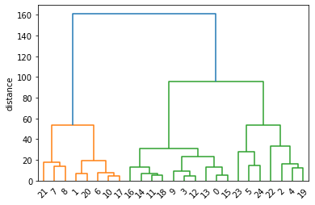

```python
model3 = AgglomerativeClustering(linkage='complete',distance_threshold=0, n_clusters=None)
model3 = model3.fit(dfAB.T)
plot_dendrogram(model3)
plt.ylabel('distance')
```

### !! grouping

```python
bothhigh =[3,6,16,23,24,25]
bothlow = [2,7,11,18,21]
AhighBlow=[1,4,5,8,9,10,12,13,14,15,20,22]
AlowBhigh=[17,19]
group = [bothhigh, bothlow,AhighBlow,AlowBhigh]
```

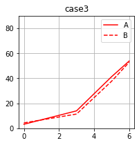

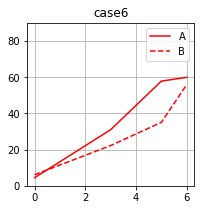

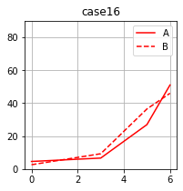

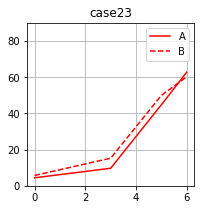

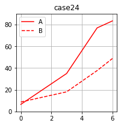

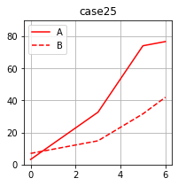

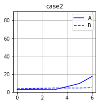

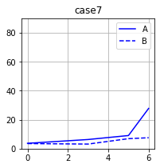

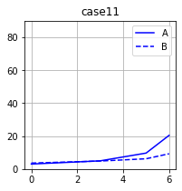

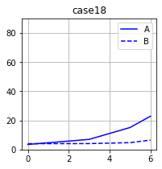

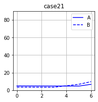

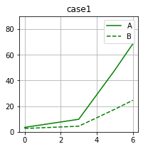

[13 more figures not shown]

```python
color = ['r','b','g','y']
for i in range(len(group)):
    label_idx = np.where(np.array(clustering3.labels_==i)==True)[0]+1
#     print(label_idx)
    for j in group[i]:
        plt.figure(figsize=(3,3))
        plt.grid(b=True)
        plt.plot(dfA[j],color[i])
        plt.plot(dfB[j],color[i]+'--')
        plt.ylim([0,90])
        plt.title("case"+str(j))
        plt.legend(['A','B'])
#         plt.savefig("case"+str(j))
        plt.show()

# adjust plot x axis
```

# predictive power of other factors (more analysis in R)

```python
# how each trial correspond to each other
# subset for A and B separately
# regress sixth strip TEWL ~ 0strip TEWL + 3rd strip TEWL + 5thstrip TEWL + ...Ery + ...Denud +..pH
```

```python
v11AB['TEWL_A'].head()
```

|  | id | IP | 0 | 3 | 5 | 6 |
| --- | --- | --- | --- | --- | --- | --- |
| 0 | 1 | A | 3.455 | 9.76 | 48.000 | 68.475 |
| 1 | 2 | A | 2.825 | 2.61 | 9.495 | 17.370 |
| 2 | 3 | A | 3.220 | 13.94 | 41.250 | 53.725 |
| 3 | 4 | A | 3.515 | 18.59 | 57.540 | 78.340 |
| 4 | 5 | A | 4.905 | 28.52 | 68.465 | 77.770 |

```python
TA = v11AB['TEWL_A'].rename(columns={"id":"ID","IP":"IP","0":"T0","3":"T3","5":"T5","6":"T6"})
EA = v11AB['Erythema_A'].rename(columns={"id":"ID","IP":"IP","0":"E0","3":"E3","5":"E5","6":"E6"})
DA = v11AB['Denudation_A'].rename(columns={"id":"ID","IP":"IP","0":"D0","3":"D3","5":"D5","6":"D6"})
all_A = pd.concat([TA,EA.iloc[:,2:],DA.iloc[:,2:],pHdf['pH']],axis=1)
all_A.to_csv('all_A.csv')
```

```python
TB = v11AB['TEWL_B'].rename(columns={"id":"ID","IP":"IP","0":"T0","3":"T3","5":"T5","6":"T6"})
EB = v11AB['Erythema_B'].rename(columns={"id":"ID","IP":"IP","0":"E0","3":"E3","5":"E5","6":"E6"})
DB = v11AB['Denudation_B'].rename(columns={"id":"ID","IP":"IP","0":"D0","3":"D3","5":"D5","6":"D6"})
all_B = pd.concat([TB,EB.iloc[:,2:],DB.iloc[:,2:],pHdf['pH']],axis=1)
all_B.to_csv('all_B.csv')
```

```python
# A
# the coefficient is not very big relative to the actual value of TEWL
# T3           -0.8664     0.3513  -2.466   0.0272 *
# T5            1.3459     0.1974   6.819 8.34e-06 ***
# B
# T5            1.0874     0.1922   5.657 5.92e-05 ***
```